# POLS 3604

Lecture 5 | Elections - Who runs?

## Plan for Today

- Discuss congressional careerism
- Examine the incumbency advantage
- Discuss the nationalization of politics

## Congressional Careerism

- The average length of time that a member of Congress spends is (for the 117th Congress):
  - 8.9 years (4.5 House terms) in the House
  - 11.0 years (1.8 Senate terms) in the Senate
- The average age of members of Congress is:
  - 58.4 years in the House
  - 64.3 years in the Senate
- Members are getting elected and staying in office for long periods of time
- Early in American political history this was not the case
  - High congressional turnover
  - Much more state government focused
    - People might spend a term in the federal government and then go back to the state government
  - Recall, the control that the parties had on this process
    - Recruited candidates and played a significant role in the careers of politicians
- The Progressive era changes
  - Secret (Australia) ballot
    - Made elected officials less reliant on parties
  - Overall decreases in party control
    - Increase in focus on constituents
  - Increased salaries of elected officials
    - Made the federal government a viable option for a career

## Political Ambition

- Members of Congress are “single-minded seekers of reelection” (Mayhew 1974)
- Deciding to run for elected office is a strategic decision
  - There are benefits and costs that must be calculated before running
    - If the benefits outweigh the costs, then a person has an incentive to run

## Types of Candidates

- Individuals that run for Congress can be broken down into two groups:
  - Quality (professional) Candidates
    - These are candidates that have previous electoral experience
  - Amateur Candidates
    - These candidates have no previous electoral experience
- Generally, quality candidates are going to outperform amateur candidates
  - There are exceptions such as AOC who defeated a Joe Crowley an incumbent
- Certain amateur candidates will fare better than others
  - astronauts, actors, entertainers, athletes, war heroes, or business leaders

## The Incumbency Advantage

- Incumbents possess an advantage in elections
  - Why?
- Institutional Advantages
  - MRAs
    - Franked mail
    - Staff
  - Name recognition
  - Credit claiming
  - Position taking
- Money
  - Campaign fundraising skills
  - People want to donate to “winners”
  - Average cost to win a House seat is roughly 2 million and 14 million for the Senate
- Redistricting
  - Districts drawn by state legislators tend to produce less competitive districts
    - Good for incumbents

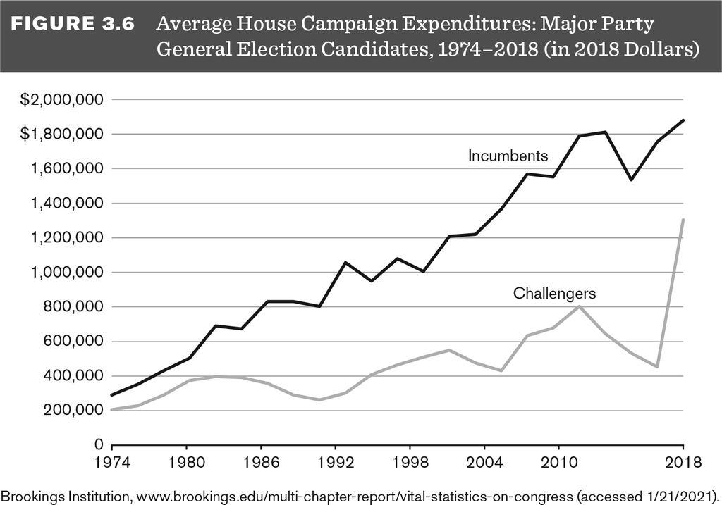

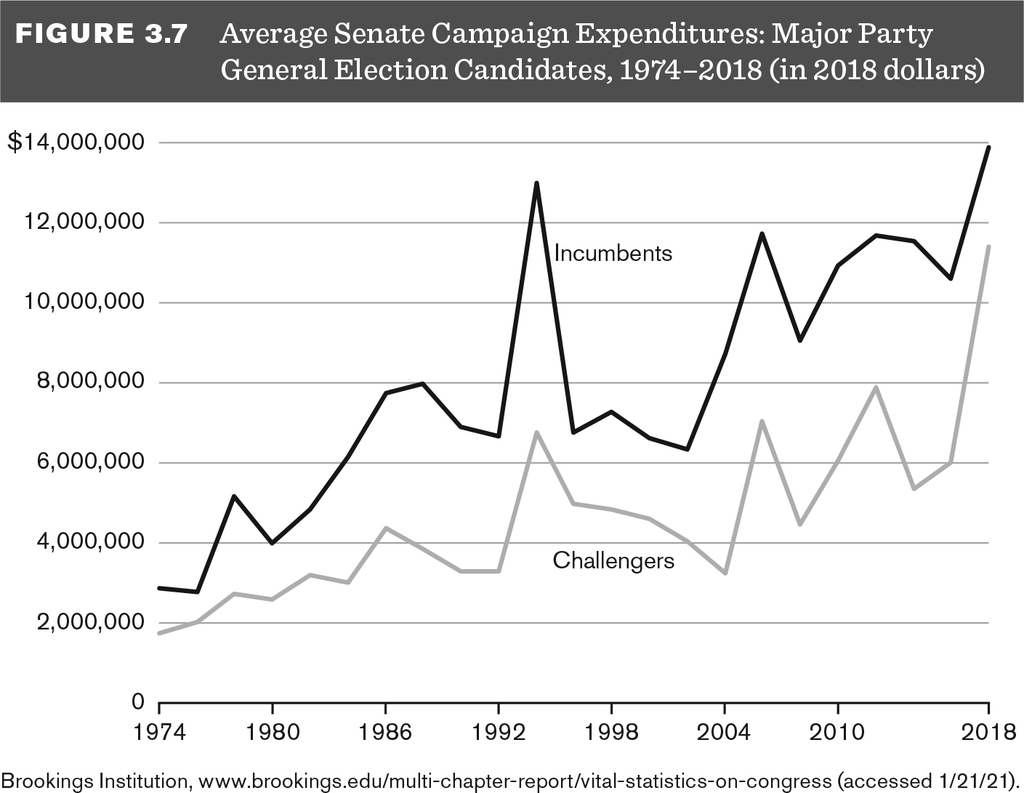

## How can Incumbents Lose?

- National tides
  - Poor economic conditions
  - Midterm elections
    - No presidential coattails
- Scandals
  - The average incumbent can expect to see their vote total drop by 5 to 11 points if they are involved in a scandal
    - That is a big margin for marginal candidates
- Redistricting
- Strategic retirements

## The Nationalization of Politics

- Voters rely more on simple partisan cues (i.e., party id) to make their vote choices
- Split-ticket voting
  - Corresponds to a decrease in voting for one party’s candidate for one office and another party’s candidate for another office
  - Decreases with increased nationalization
- What causes it?
  - Some scholars believe it is due to shifts in the electorate
    - Citizens become more loyal to a given party
  - Some scholars believe it is due to the elites
    - Party leaders in Congress have emphasized party loyalty as a requirement for members to advance in the chamber and receive rewards

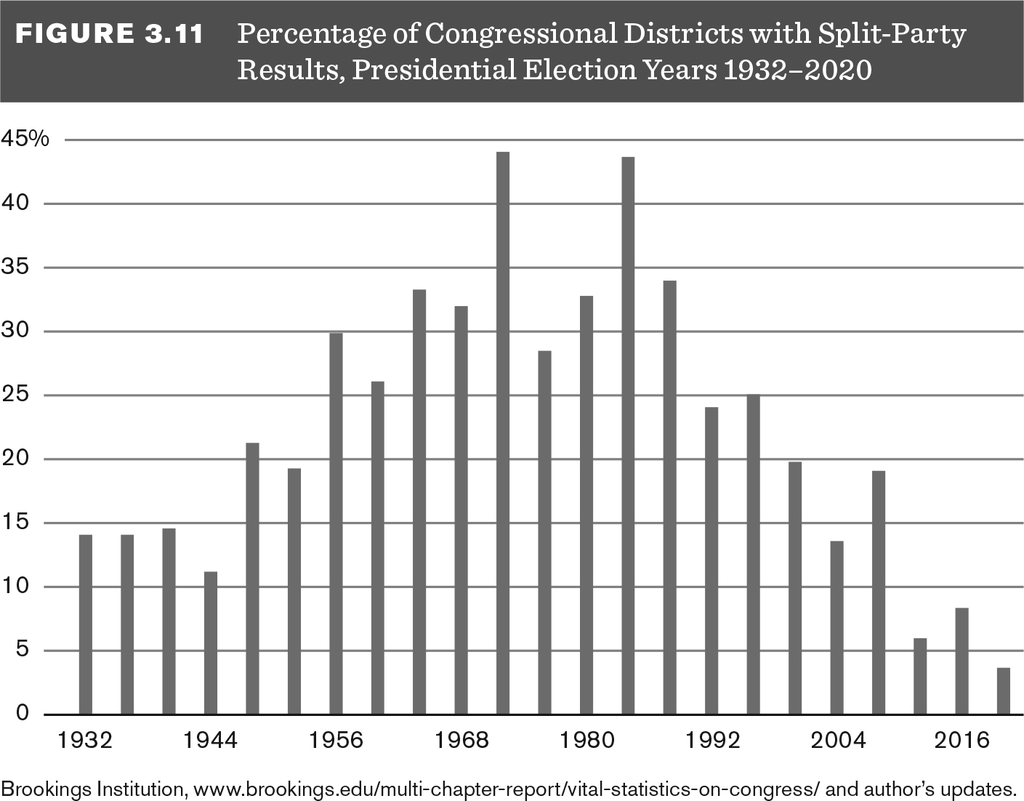

## Final Thoughts

- Elected officials have increasingly turned to Congress as life long careers
- Incumbents are greatly advantaged as it pertains to elections
- Nationalization creates increases in partisanship

## What Do You Need to Do For Next Class?

- Read Chapter 4 TUSC
- Congressional Simulation - Who are you as a Senator?